# MY FIRST DATA STORY ;-)

## DATA WILL TALK TO YOU ~ IF YOUR WILLING TO LISTEN!!

### *Nandhitha*

## Believe me, this Ford GoBike System data spoke to me :p

## And I wanted to share his story to you

## HERE'S HIS STORY >>>>

## He told me, he had lots of memories about the people who would visit him (Subscribers and Customers)!

## He nearly had 230000+ incidents relating to bike trips of Subscribers and Customers.

## So now, I was curious and asked him a few questions...

## Hey, So when do most of them ride? 🤔

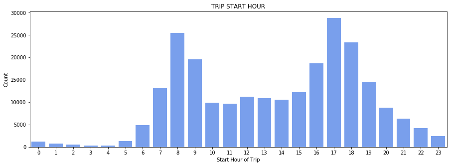

```python
# memory1

plt.subplots(figsize = (15,5))
sns.countplot(data=new_df, x='trip_hour', color='#6698FF')
plt.title('TRIP START HOUR')
plt.xlabel('Start Hour of Trip')
plt.ylabel('Count');
```

> **"Most of the bikers who I met prefer 5:00 pm for rides, followed by 8:00 am. Probably, is it beacuse most of them prefered bike rides on the purpose of work!", he said.**

# For work!

# So, How about the rides on Weekends when there's no work? 🤔

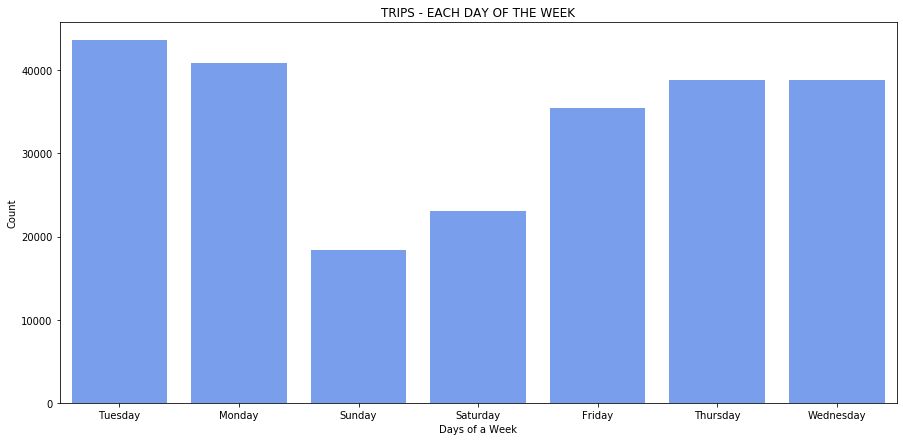

```python
# memory2

plt.subplots(figsize = (15,7))
sns.countplot(data = new_df, x = 'day_of_week', color = '#6698FF')
plt.title('TRIPS - EACH DAY OF THE WEEK')
plt.xlabel('Days of a Week')
plt.ylabel('Count');
```

> **He said,**

> **I have a memory of least number of rides on Sundays followed by Saturdays!**

> **Most of the bike rides have been on Tuesdays. And secondly, Mondays have the most number of rides. And also, there were approximately equal propotion of rides on Wednesdays and Thursdays.**

# May be people tend to relax and stay at home in the weekends!

# So, who do you think uses the rides more often? 🤔

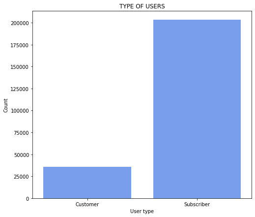

```python
# memory3

plt.subplots(figsize = (8,7))
sns.countplot(data = new_df, x = 'user_type', color = '#6698FF')
plt.title('TYPE OF USERS')
plt.xlabel('User type')
plt.ylabel('Count');
```

> **He said,**

> **"As as as I remember, Subscribers of 'Ford GoBike' seem to use the service of bike rides more than the Customers(those who use it rarely). This might be probably the subscribers were more used to the rides, found it comfortable and also enjoyed subscription discounts than the normal customers!"**

# Subscribers!

# What do you think about the subscriber's and customer's activities? 🤔

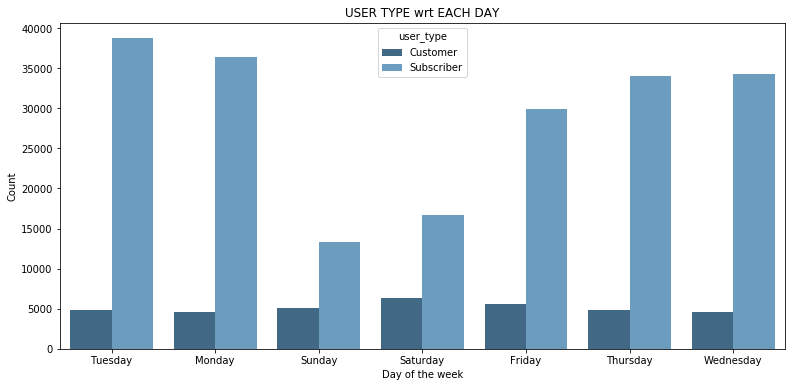

```python
# memory4

plt.subplots(figsize = (13,6))
sns.countplot(data=new_df, x='day_of_week', hue='user_type', palette="Blues_d")
plt.title('USER TYPE wrt EACH DAY')
plt.xlabel('Day of the week')
plt.ylabel('Count');
```

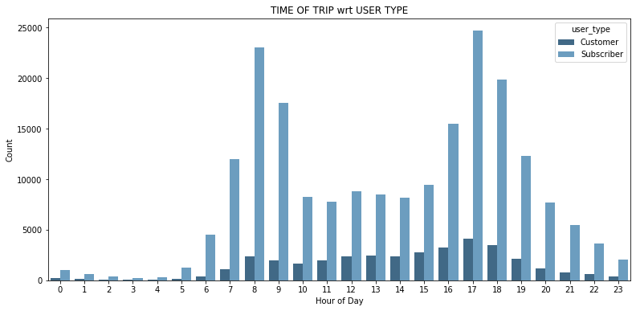

```python
# memory5

plt.subplots(figsize = (13,6))
sns.countplot(data=new_df, x='trip_hour', hue='user_type', palette="Blues_d")
plt.title('TIME OF TRIP wrt USER TYPE')
plt.xlabel('Hour of Day')
plt.ylabel('Count');
```

> **As I already told you, most of the bike rides are on working days by the subsribers at rush hours(8:00 am and 5:00 pm), so I am sure they have the purpose of going to and returning from office.**

> **The customers are interested to use the bike service preferably on Saturdays, and it may be for recreational purposes!", he told me.**

# Recreational activities on Weekends is great!

# What do you think is the average time of a ride? 🤔

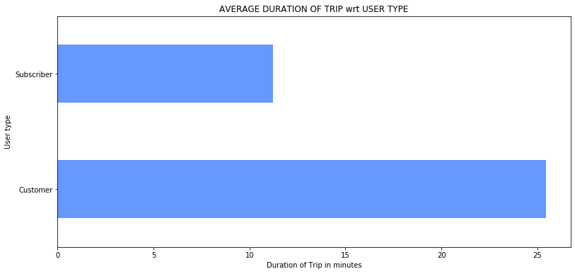

```python
# memory6

avg = new_df.groupby('user_type')['trip_duration_minute'].mean().plot(kind='barh', color='#6698FF', figsize=(13,6))
avg.set_title('AVERAGE DURATION OF TRIP wrt USER TYPE')
avg.set_ylabel('User type',)
avg.set_xlabel('Duration of Trip in minutes');
```

> **"The average trip duration of subscribers is nearly 12 minutes and the average trip duration of customers is nearly 26 minutes.**

> **This may be because most of the customers use the bike rides when they have to travel far!", he guessed!**

# Who do you think utilizes or enjoys the bike rides effectively?🤔

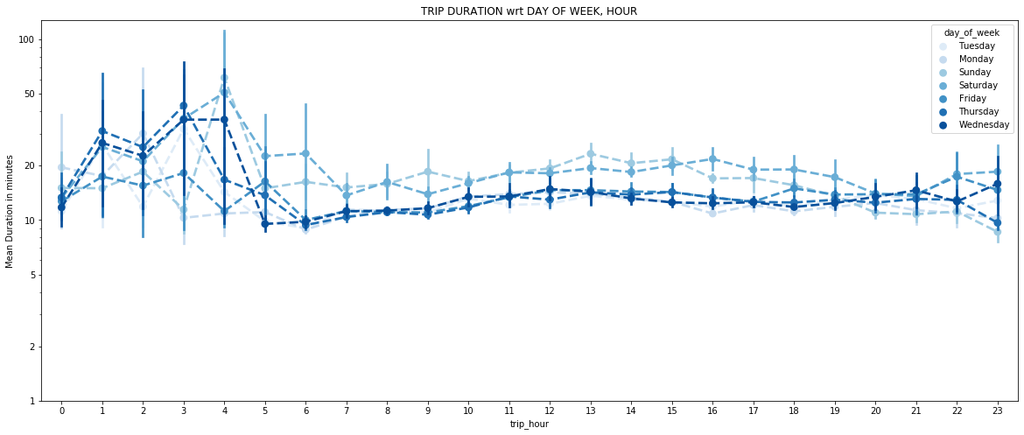

```python
# memory7

plt.subplots(figsize = (20,8))
ax = sns.pointplot(data = new_df, x = 'trip_hour', y = 'trip_duration_minute', hue = 'day_of_week',palette = 'Blues', linestyles = '--')
plt.title('TRIP DURATION wrt DAY OF WEEK, HOUR')
plt.ylabel('Mean Duration in minutes')
plt.yscale('log')
plt.yticks([1, 2, 5, 10, 20, 50, 100], [1, 2, 5, 10, 20, 50, 100])
ax.set_yticklabels([],minor = True);
```

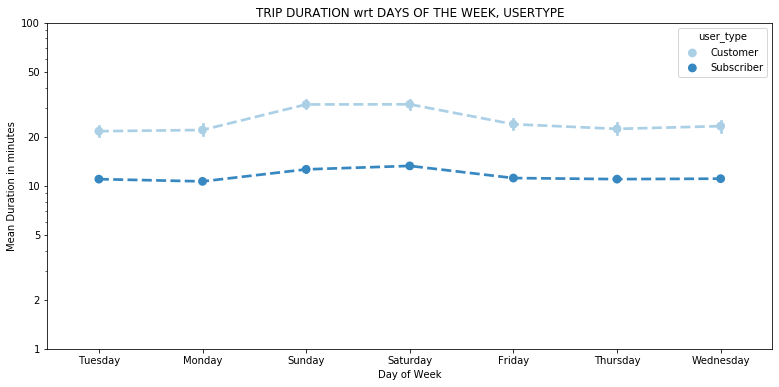

```python
# memory8

plt.subplots(figsize = (13,6))
ax = sns.pointplot(data = new_df, x = 'day_of_week', y = 'trip_duration_minute', hue = 'user_type', palette = 'Blues', linestyles = '--')
plt.title('TRIP DURATION wrt DAYS OF THE WEEK, USERTYPE')
plt.ylabel('Mean Duration in minutes')
plt.xlabel('Day of Week')
plt.yscale('log')
plt.yticks([1, 2, 5, 10, 20, 50, 100], [1, 2, 5, 10, 20, 50, 100])
ax.set_yticklabels([],minor = True);
```

> **I can notice that subscribers ride much shorter or quicker trips everyday of the week compared to those of the customers rides.**

> **The activity of customers (casual riders) seem to increase on weekends (Saturdays, Sundays) an the activities of the subscribers seem to be more efficient and consistent wrt average duration of their trips from Monday through Friday",he concluded**

# Nice meeting you 'Ford GoBike Data' !!

# I hope you guys loved him and the story he told us :-)

# I'll meet you again with some other interesting Story